# Comparando mecanismos para jukebox sociais

```r
dados = read_csv(here::here("data/satisfacoes.csv"),
                 col_types = "cdcc")

glimpse(dados)
```

```
## Observations: 115
## Variables: 4
## $ user_id      <chr> "1", "2", "3", "4", "5", "6", "7", "8", "9", "10", "11...
## $ satisfaction <dbl> 2.0, 3.0, 1.5, 1.0, 2.0, 2.5, 2.0, 3.0, 2.0, 2.0, 2.0,...
## $ scenario     <chr> "baseline", "baseline", "baseline", "baseline", "basel...
## $ group        <chr> "3", "1", "2", "2", "1", "1", "3", "3", "2", "1", "3",...
```

Analisando a distribuição da variável satisfação para cada método, temos:

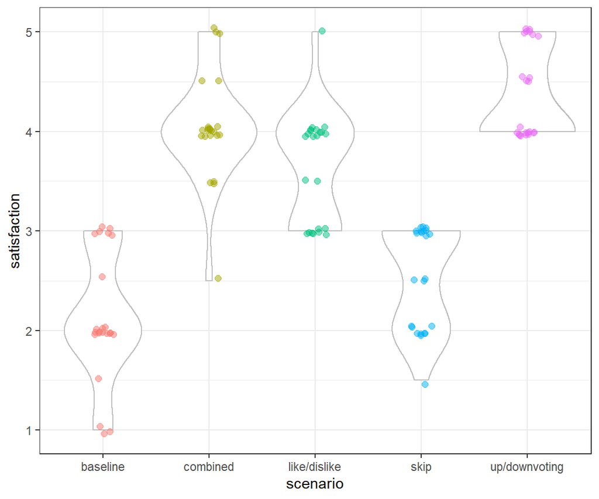

```r
dados = dados %>% arrange(scenario,satisfaction)


ggplot() +
    geom_violin(data = dados, mapping = aes(x=scenario,y=satisfaction),alpha = 1,colour = "gray")+
    geom_jitter(data = dados,mapping = aes(colour= scenario, x=scenario,y=satisfaction),alpha = 0.5,size = 2,height = 0.05, width = 0.1, show.legend = FALSE)
```

A partid do gráfico podemos notar que os métodos up/downvoting, like/dislike e combined apresentam uma satisfação maior que o baseline. Para confirmar está observação vamos aplicar o teste de Mann-Whitney, com significância de 0.05, para comprovar que existe uma diferença significante.

1. Baseline x (Like/dislike, up/downvoting, combined)

```r
comparacao1 = dados %>%
    filter(scenario %in% c("baseline", "like/dislike"))
comparacao2 = dados %>%
    filter(scenario %in% c("baseline", "up/downvoting"))
comparacao3 = dados %>%
    filter(scenario %in% c("baseline", "combined"))



dif <- function(d) {

    wilcox.test(satisfaction ~ scenario,
            data=d)

}

dif(comparacao1)
```

```
##
##  Wilcoxon rank sum test with continuity correction
##
## data:  satisfaction by scenario
## W = 24, p-value = 5.07e-08
## alternative hypothesis: true location shift is not equal to 0
```

```r
dif(comparacao2)
```

```
##
##  Wilcoxon rank sum test with continuity correction
##
## data:  satisfaction by scenario
## W = 0, p-value = 3.125e-09
## alternative hypothesis: true location shift is not equal to 0
```

```r
dif(comparacao3)
```

```
##
##  Wilcoxon rank sum test with continuity correction
##
## data:  satisfaction by scenario
## W = 6.5, p-value = 6.627e-09
## alternative hypothesis: true location shift is not equal to 0
```

Como as 3 comparações apresentaram p-valor < 0.05 podemos rejeitar a hipótese nula, confirmando que os valores de satisfação das amostras like/dislike, up/downvoting/combined são diferentes do baseline.

Além disso, com base na visualização da distribuição dos 5 cenários, podemos perceber que o método up/downvoting, além de um alto nível de satisfação, ainda apresentou uma dispersão menor que os outros métodos. Aplicando a técnica de bootstrapping na média dos métodos up/downvoting, combined e like/dislike separadamente, temos:

2. Up/downvoting

```r
set.seed(12345)

theta = function(d,i) {
  mean(d %>% slice(i) %>% pull(satisfaction))
}

updown = dados %>%
    filter(scenario == "up/downvoting")

ciupdown = boot(data = updown,
           statistic = theta,
           R = 2000) %>%
    tidy(conf.level = .95,
         conf.method = "bca",
         conf.int = TRUE)

ciupdown = ciupdown %>% mutate(metodo = "up/downvoting")
```

3. Like/dislike

```r
set.seed(12345)

likedis = dados %>%
    filter(scenario == "like/dislike")

cilikedis = boot(data = likedis,
           statistic = theta,
           R = 2000) %>%
    tidy(conf.level = .95,
         conf.method = "bca",
         conf.int = TRUE)

cilikedis = cilikedis %>% mutate(metodo = "like/dislike")
```

4. Combined

```r
set.seed(12345)
combined = dados %>%
    filter(scenario == "combined")

cicombined = boot(data = combined,
           statistic = theta,
           R = 2000) %>%
    tidy(conf.level = .95,
         conf.method = "bca",
         conf.int = TRUE)

cicombined = cicombined %>% mutate(metodo = "combined")
```

```r
dfCompara = rbind(ciupdown, cicombined, cilikedis)
dfCompara
```

```
## # A tibble: 3 x 6
##   statistic      bias std.error conf.low conf.high metodo
##       <dbl>     <dbl>     <dbl>    <dbl>     <dbl> <chr>
## 1      4.39  0.000239    0.0936     4.20      4.57 up/downvoting
## 2      4.04 -0.00336     0.109      3.78      4.22 combined
## 3      3.65  0.000663    0.112      3.41      3.85 like/dislike
```

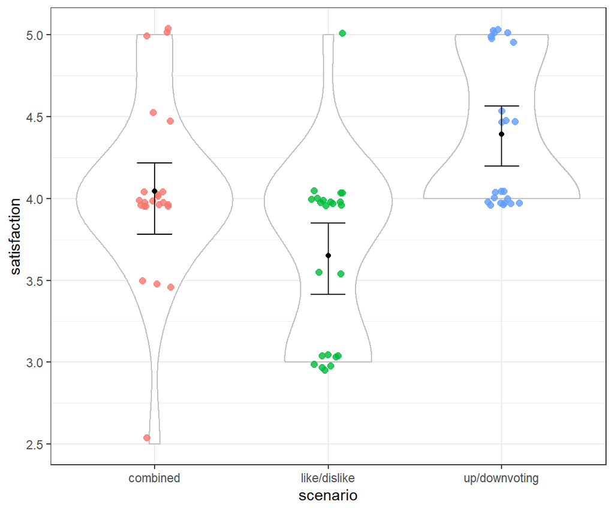

```r
df3best = dados %>% filter(scenario %in% c("up/downvoting", "like/dislike","combined"))

#dfCompara %>% ggplot(aes(
#        x = metodo,
#        y = statistic,
#        ymin = conf.low,
#        ymax = conf.high
 #   )) +
 #   geom_pointrange(size = 1.2) +
 #   geom_point(size = 3) +
 #   labs(x = "Nível de Satisfação x Método de Gerenciamento",
 #        y = "")

ggplot() +
    geom_violin(data = df3best, mapping = aes(x=scenario,y=satisfaction),colour = "gray")+
    geom_jitter(data = df3best,mapping = aes(colour= scenario, x=scenario,y=satisfaction),alpha = 0.8,size = 2,height = 0.05, width = 0.1, show.legend = FALSE)+
    geom_errorbar(data = dfCompara, mapping = aes( x = metodo,y = statistic,ymin = conf.low,ymax = conf.high),width = 0.2)+
    geom_point(data = dfCompara,size = 1.5,aes( x = metodo,y = statistic) )
```

Sendo assim, com base nas visualizações geradas, podemos perceber uma vantagem na satisfação do método Up/downvoting em relação aos outros métodos, considerando um intervalo de confiança de 95%.

## Teste-t para diferença entre médias

Usando o teste-t para saber se a média de satisfação do método up/downvoting é maior que os métodos combined e like/dislike, podemos formular as seguintes hipóteses:

H0: MediaUpDown - MediaMetodo = 0 H1: MediaUpDown - MediaMetodo > 0

Onde MediaMetodo corresponder a média do método combined ou like/dislike. Com base num nível de significancia de 0.05, temos:

```r
conf = 0.05
TupDown = dados %>% filter( scenario == "up/downvoting") %>% pull(satisfaction)
Tcombined = dados %>% filter( scenario == "combined") %>% pull(satisfaction)

t_test1 = t.test(TupDown, Tcombined, alternative = "greater", conf.level = conf)
t_test1
```

```
##
##  Welch Two Sample t-test
##
## data:  TupDown and Tcombined
## t = 2.3661, df = 42.606, p-value = 0.0113
## alternative hypothesis: true difference in means is greater than 0
## 5 percent confidence interval:
##  0.595001      Inf
## sample estimates:
## mean of x mean of y
##  4.391304  4.043478
```

```r
Tlikedis = dados %>% filter( scenario == "like/dislike") %>% pull(satisfaction)

t_test2 = t.test(TupDown, Tlikedis, alternative = "greater", conf.level = conf)
t_test2
```

```
##
##  Welch Two Sample t-test
##
## data:  TupDown and Tlikedis
## t = 4.969, df = 42.308, p-value = 5.795e-06
## alternative hypothesis: true difference in means is greater than 0
## 5 percent confidence interval:
##  0.9892755       Inf
## sample estimates:
## mean of x mean of y
##  4.391304  3.652174
```

Como ambos os casos apresentaram p-valor (0.01 e 5.79*10^6) menor que o nível de significância, podemos rejeitar a hipótese nula, reforçando a tese de que o método up/downsvoting apresentou uma média de satisfação significantemente maior que os outros métodos.